# Chicago TNC Data

Morteza Taiebat

# Ridesourcing Trip Data from City of Chicago

Data comes from the ridehailing trip records on the City of Chicago’s [open data portal](https://data.cityofchicago.org/Transportation/Transportation-Network-Providers-Trips/m6dm-c72p). Ridehailing data is available through Dec 31, 2019 now but regularly updates (Q1 2020 is delayed.) Each trip record comes with 21 variables. Pick up and drop off are record in the Census Tract (with GPS coordinates). Census Tracts are suppressed in some cases, and times are rounded to the nearest 15 minutes (while trip seconds are accurate). Fares are rounded to the nearest $2.50 and tips are rounded to the nearest 1.00.

I use the American Community Survey 2014–2018 5-year estimates data (specifically 2018 adjustments) for each census tract whenever I need socioeconomic and demographic variables.

```r
require(tidycensus)
v18 <- load_variables(2018, "acs5", cache = TRUE)
```

Call all required packages:

```r
packages <- c("tidyverse", "tidycensus", "tigris", "sp", "scales",
              "ggspatial", "lubridate", "cowplot")
invisible(lapply(packages, require, character.only=TRUE, quietly=TRUE,
                 warn.conflicts = FALSE))
```

## Trips in Nov 2019

All trips started from 11/1/2019 00:00 to 11/30/2019 23:59 (one month worth of data) are included. The raw dataset has 9,309,804 with 21 variables.

```r
setwd("/Users/taiebat/Desktop/")
load("TNC_Trips_data.RData")
```

Since dataset is large, we can also use a more efficient way of reading data using `ff` package to save the memory:

```r
## to open a large file
# library(ff)
# data <- read.csv.ffdf(file="TNC_Trips.csv")
# ffsave(data, file = "data")
```

Let’s see a glimpse of dataset:

```r
tibble::glimpse(data)
```

```
## Observations: 9,309,804
## Variables: 21
## $ Trip.ID                    <fct> fff0e410648f4174f0dae727866bcfbc555d56a4, …
## $ Trip.Start.Timestamp       <fct> 11/01/2019 12:00:00 AM, 11/01/2019 12:00:0…
## $ Trip.End.Timestamp         <fct> 11/01/2019 12:00:00 AM, 11/01/2019 12:15:0…
## $ Trip.Seconds               <int> 165, 823, 683, 545, 768, 420, 561, 380, 83…
## $ Trip.Miles                 <dbl> 0.6, 5.4, 5.6, 1.8, 4.5, 2.6, 2.3, 1.5, 6.…
## $ Pickup.Census.Tract        <dbl> 17031320600, 17031032100, 17031100700, 170…
## $ Dropoff.Census.Tract       <dbl> 17031320400, 17031081800, 17031160800, 170…
## $ Pickup.Community.Area      <int> 32, 3, 10, 8, 6, 8, 33, 24, 3, 22, 6, 6, N…
## $ Dropoff.Community.Area     <int> 32, 8, 16, 8, 8, 24, 35, 24, 32, 6, 6, 32,…
## $ Fare                       <dbl> 2.5, 10.0, 10.0, 5.0, 10.0, 7.5, 7.5, 10.0…
## $ Tip                        <int> 0, 0, 3, 0, 0, 3, 0, 0, 1, 0, 0, 0, 0, 0, …
## $ Additional.Charges         <dbl> 2.55, 2.55, 2.55, 2.55, 2.55, 2.55, 2.55, …
## $ Trip.Total                 <dbl> 5.05, 12.55, 15.55, 7.55, 12.55, 13.05, 10…
## $ Shared.Trip.Authorized     <fct> false, false, false, false, false, false, …
## $ Trips.Pooled               <int> 1, 1, 1, 1, 1, 1, 1, 1, 1, 1, 1, 1, 2, 1, …
## $ Pickup.Centroid.Latitude   <dbl> 41.87061, 41.95815, 41.97213, 41.89204, 41…
## $ Pickup.Centroid.Longitude  <dbl> -87.62217, -87.65302, -87.79763, -87.63186…
## $ Pickup.Centroid.Location   <fct> POINT (-87.6221729369 41.8706073724), POIN…
## $ Dropoff.Centroid.Latitude  <dbl> 41.87741, 41.89322, 41.95021, 41.90741, 41…
## $ Dropoff.Centroid.Longitude <dbl> -87.62197, -87.63784, -87.71281, -87.64090…
## $ Dropoff.Centroid.Location  <fct> POINT (-87.6219716519 41.8774061234), POIN…
```

### Manipulate Timestamps

I use the package `lubridate` to transform the timestamps. Then extract the date and time of start for each trip. I also find the week day of each trip in order to use for aggregate analysis (reorder the factors so the week starts on Monday). Finally, I remove the original timestamps to reduce the size dataset.

```r
data$start <- parse_date_time(data$Trip.Start.Timestamp, "%m/%d/%Y %I:%M:%S %p")
data$end <- parse_date_time(data$Trip.End.Timestamp, "%m/%d/%Y %I:%M:%S %p")
# Alternative timestamp transformartion
# data$start <- as.POSIXct(data$Trip.Start.Timestamp, format = "%m/%d/%Y %I:%M:%S %p")

data$start.date <- as.Date(data$start, format = "%Y-%m-%d  %H:%M:%S")
data$start.time <- format(as.POSIXct(strptime(data$start,
                                               "%Y-%m-%d  %H:%M:%S",tz="")),
                          format = "%H:%M")
data$start.time <- as.POSIXct(data$start.time, format = "%H:%M")
str(data$start.time)
# find week day
data$start.day <- wday(data$start.date, label = T) # we use labels=true here to return day labels instead of numeric values.
data$start.day <- factor(data$start.day, levels = c("Mon", "Tue", "Wed", "Thu", "Fri", "Sat", "Sun"))

# manipulate end time
data$end.date <- as.Date(data$end, format = "%Y-%m-%d  %H:%M:%S")
data$end.time <- format(as.POSIXct(strptime(data$end,
                                              "%Y-%m-%d  %H:%M:%S",tz="")) ,
                          format = "%H:%M")
data$end.time <- as.POSIXct(data$end.time, format = "%H:%M")

## remove start dates on 12/1/2019
data<-data %>%
  filter(start < as.Date("2019-12-01")) %>%
  select(-c("Trip.End.Timestamp", "Trip.Start.Timestamp"))
```

## Summary Statistics

The following chunk of code reveals the summary statistics of key variables before data cleaning:

```r
summary(data$Trip.Seconds)
```

```
##    Min. 1st Qu.  Median    Mean 3rd Qu.    Max.    NA's
##       0     540     872    1087    1402   64980    3555
```

```r
summary(data$Trip.Miles)
```

```
##    Min. 1st Qu.  Median    Mean 3rd Qu.    Max.
##   0.000   1.800   3.800   6.481   8.300 422.000
```

```r
summary(data$Trips.Pooled)
```

```
##    Min. 1st Qu.  Median    Mean 3rd Qu.    Max.
##   1.000   1.000   1.000   1.132   1.000  10.000
```

```r
summary(data$Trip.Total)
```

```
##    Min. 1st Qu.  Median    Mean 3rd Qu.    Max.    NA's
##    0.72    8.55   12.55   15.54   17.55  702.10       5
```

```r
summary(data$Fare)
```

```
##    Min. 1st Qu.  Median    Mean 3rd Qu.    Max.    NA's
##     0.0     5.0    10.0    11.9    15.0   700.0       5
```

```r
summary(data$Tip)
```

```
##     Min.  1st Qu.   Median     Mean  3rd Qu.     Max.     NA's
##   0.0000   0.0000   0.0000   0.6561   0.0000 100.0000        5
```

```r
summary(data$Additional.Charges)
```

```
##    Min. 1st Qu.  Median    Mean 3rd Qu.    Max.    NA's
##   0.000   2.550   2.550   2.986   2.550  30.690       2
```

```r
data$speed <- (data$Trip.Miles/(data$Trip.Seconds/3600))
summary(data$speed)
```

```
##    Min. 1st Qu.  Median    Mean 3rd Qu.    Max.    NA's
##    0.00   11.63   15.86     Inf   23.27     Inf    3609
```

## Data Cleaning Procedure

The data include instance of missing values and incorrect observations. I attempt to clean the dataset through these iterative steps: * remove trips with total trip time less than 1 minutes and longer than 5 hours * remove trips less total distance traveled than 0.25 miles and greater than 300 miles * remove trips with total fare equal to zero (fares are already rounded) * remove trips with extreme speeds (below 0.2 mph and above 80 mph)

I also create a new variable to whether the trip was pooled or not: `pooled` This variable is zero for solo trips and 1 for any number of shares. Please note that the traveler could authorize a shared trip but no matching could be made through the trip (variable `Shared.Trip.Authorized` could be true or false).

Finally I save the cleaned dataset for ease of future use:

```r
data <- data %>%
  filter( Trip.Seconds < 5*3600, Trip.Seconds > 60) %>% # remove trips less than 60 secs or 5 hours
  filter(Trip.Miles < 300 , Trip.Miles > 0.25 ) %>%  # remove trips with extreme or zero miles
  filter(Trip.Total > 0) %>% # trip total greater than zero
  filter(Trip.Miles/(Trip.Seconds/3600) < 80,
         Trip.Miles/(Trip.Seconds/3600) > 0.2) # remove trips with extreme speeds

summary(data$Trip.Miles/(data$Trip.Seconds/3600))

data <- data %>% mutate("pooled" = ifelse(Trips.Pooled > 1, yes = 1, no = 0)) # mutate a column to show whether the trip was pooled or not

save(data, file = "TNC_Trips_data_clean.RData")
```

The cleaned dataset has the record of *9,270,476* trips with 28 variables. * *Note* some trips may start and/or end *out* of the census tracts of the City of Chicago. This observations do not have a record of start and end location. For now, I do not remove them but in extraction of O-D pairs, they will be removed.

Load clean data:

```r
rm(data)
load("TNC_Trips_data_clean.RData")
```

- Daily number of trips, total fares and total transactions:

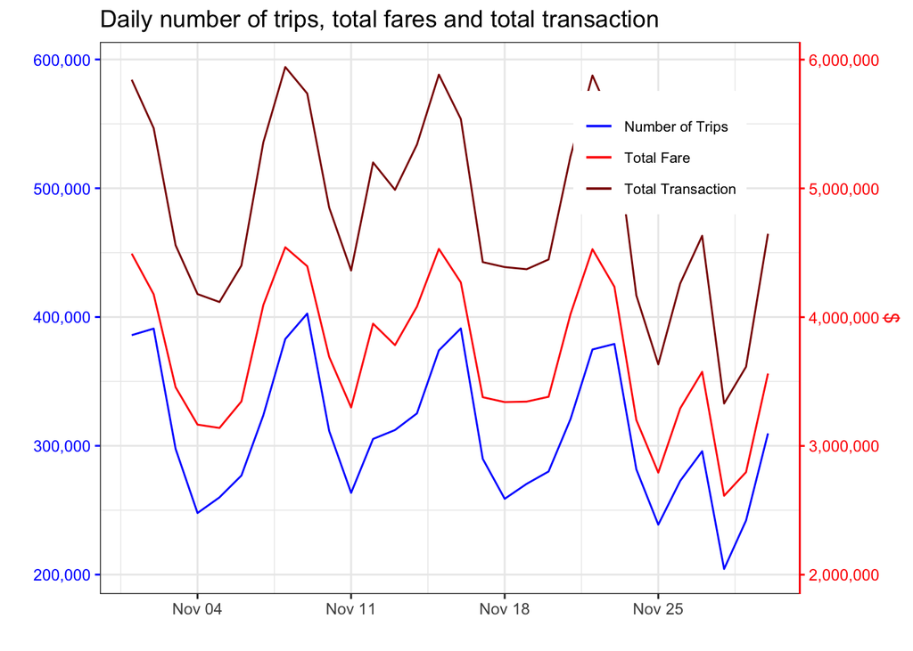

```r
invisible(lapply(packages, require, character.only=TRUE, quietly=TRUE,
                 warn.conflicts = FALSE))
data %>%
  group_by(day=floor_date(start, "day")) %>%
  summarise("Daily_Trips" = n(),
            "Transaction" = sum(Trip.Total, na.rm = T),
            "Total_Fare" = sum(Fare, na.rm = T)) %>%
  ggplot(aes(x = day)) +
  geom_line(aes(y = Daily_Trips, color = "Number of Trips")) +
  geom_line(aes(y = Transaction/10, color = "Total Transaction")) +
  geom_line(aes(y = Total_Fare/10, color = "Total Fare")) +
  scale_colour_manual(values = c("blue", "red", "darkred")) +
  scale_y_continuous(labels = comma,
                     sec.axis = sec_axis(~.*10, name = "$", labels = comma))+ theme_bw()+
  theme(legend.position = c(0.8, 0.8), axis.line.y.right = element_line(color = "red"),
        axis.ticks.y.right = element_line(color = "red"),
        axis.text.y.right = element_text(color = "red"),
        axis.title.y.right = element_text(color = "red"),
        axis.ticks.y.left = element_line(color = "blue"),
        axis.text.y.left = element_text(color = "blue"),
        axis.title.y.left = element_text(color = "blue"),
        legend.title = element_blank(), legend.text=element_text(size=8)) +
  labs(title = "Daily number of trips, total fares and total transaction",
              y = "",
              x = "")
```

```r
#+ scale_x_date(breaks=date_breaks("week"))
```

- Hourly number of trips, total fares and total transactions:

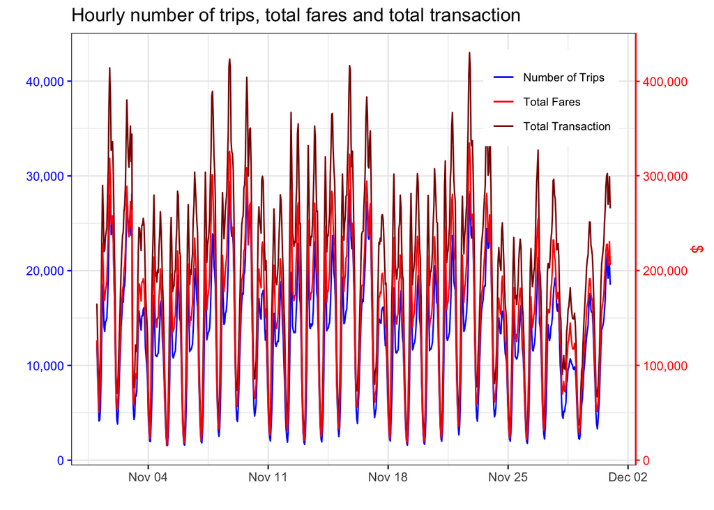

```r
data %>%
  group_by(hour=floor_date(start, "hour")) %>%
  summarise("Daily_Trips" = n(),
            "Transaction" = sum(Trip.Total, na.rm = T),
            "Total_Fare" = sum(Fare, na.rm = T)) %>%
  ggplot(aes(x = hour)) +
  geom_line(aes(y = Daily_Trips, color = "Number of Trips")) +
  geom_line(aes(y = Transaction/10, color = "Total Transaction")) +
  geom_line(aes(y = Total_Fare/10, color = "Total Fares")) +
  scale_colour_manual(values = c("blue", "red", "darkred")) +
  scale_y_continuous(labels = comma,
                     sec.axis = sec_axis(~.*10, name = "$", labels = comma))+ theme_bw()+
  theme(legend.position = c(0.85, 0.85), axis.line.y.right = element_line(color = "red"),
        axis.ticks.y.right = element_line(color = "red"),
        axis.text.y.right = element_text(color = "red"),
        axis.title.y.right = element_text(color = "red"),
        axis.ticks.y.left = element_line(color = "blue"),
        axis.text.y.left = element_text(color = "blue"),
        axis.title.y.left = element_text(color = "blue"),
        legend.title = element_blank(),
        legend.text=element_text(size=8)) +
  labs(title = "Hourly number of trips, total fares and total transaction",
              y = "",
              x = "")
```

- Total number of trips, total fares and total transactions by hour:

Note two peaks: + Around 8:30 AM + Around 5:30 PM The afternoon peak is higher than morning unlike personal vehicle peak travel.s

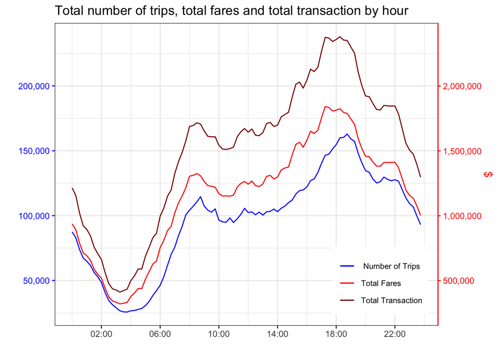

```r
data %>%
  group_by(start.time) %>%
  summarise("Daily_Trips" = n(),
            "Transaction" = sum(Trip.Total, na.rm = T),
            "Total_Fare" = sum(Fare, na.rm = T)) %>%
  ggplot(aes(x = start.time)) +
  geom_line(aes(y = Daily_Trips, color = " Number of Trips")) +
  geom_line(aes(y = Transaction/10, color = "Total Transaction")) +
  geom_line(aes(y = Total_Fare/10, color = "Total Fares")) +
  scale_colour_manual(values = c("blue", "red", "darkred")) +
  scale_y_continuous(labels = comma,
                     sec.axis = sec_axis(~.*10, name = "$", labels = comma))+
  theme_bw()+
  theme(legend.position = c(0.85, 0.15),
        axis.line.y.right = element_line(color = "red"),
        axis.ticks.y.right = element_line(color = "red"),
        axis.text.y.right = element_text(color = "red"),
        axis.title.y.right = element_text(color = "red"),
        axis.ticks.y.left = element_line(color = "blue"),
        axis.text.y.left = element_text(color = "blue"),
        axis.title.y.left = element_text(color = "blue"),
        legend.title = element_blank(), legend.text=element_text(size=8)) +
  scale_x_datetime(breaks=date_breaks("4 hour"),  date_labels = "%H:%M") +
  labs(title =  "Total number of trips, total fares and total transaction by hour",
              y = "",
              x = "")
```

It is interesting that the aggregate numbers in every day and every hour have such a similar profile. The following code shows that the correlation between `Fare`, `Additional.Charges`, and `Tip` is not high (around 0.4). However, `Fare` and `Trip.Total` have high correlation.

```r
cor(data$Fare, data$Additional.Charges, use = "complete.obs", method = c("pearson") )
```

```
## [1] 0.4897521
```

```r
cor(data$Fare, data$Tip, use = "complete.obs", method = c("pearson") )
```

```
## [1] 0.3351628
```

```r
cor(data$Fare, data$Trip.Total, use = "complete.obs", method = c("pearson") )
```

```
## [1] 0.9727284
```

```r
#cor(data1$Total_Fare, data1$Transaction, use = "complete.obs", method = c("pearson") )
#cor(data2$Total_Fare, data2$Transaction, use = "complete.obs", method = c("pearson") )
```

### Characteristics of Trips each Day

Below figures show the mean and median of some trip characteristics

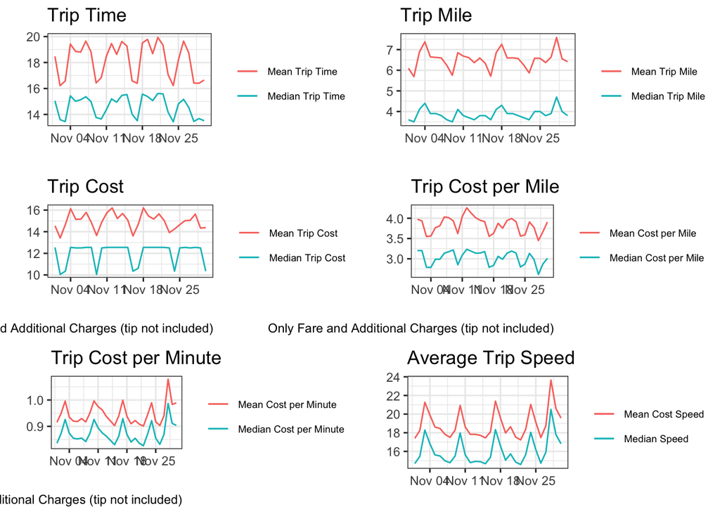

```r
a1 <- data %>%
  group_by(day=floor_date(start, "day")) %>%
  summarise("mean.minute" = mean(Trip.Seconds/60, na.rm = T),
            "median.minute" = median(Trip.Seconds/60, na.rm = T)) %>%
  ggplot(aes(x = day)) +
  geom_line(aes(y = mean.minute, color = "Mean Trip Time"))+
  geom_line(aes(y = median.minute, color = "Median Trip Time")) +
  theme_bw()+
  theme(#legend.position = c(0.85, 0.15),
        legend.title = element_blank(),
        legend.text=element_text(size=7) ) +
  labs(title =  "Trip Time",
              y = "",
              x = "")


a2 <- data %>%
  group_by(day=floor_date(start, "day")) %>%
  summarise("mean.mile" = mean(Trip.Miles, na.rm = T),
            "median.mile" = median(Trip.Miles, na.rm = T)) %>%
  ggplot(aes(x = day)) +
  geom_line(aes(y = mean.mile, color = "Mean Trip Mile"))+
  geom_line(aes(y = median.mile, color = "Median Trip Mile")) +
  theme_bw()+
  theme(#legend.position = c(0.85, 0.15),
        legend.title = element_blank(),
        legend.text=element_text(size=7) )+
  labs(title =  "Trip Mile",
              y = "",
              x = "")


a3 <- data %>%
  group_by(day=floor_date(start, "day")) %>%
  summarise("mean.cost" = mean(Fare+Additional.Charges, na.rm = T),
            "median.cost" = median(Fare+Additional.Charges, na.rm = T)) %>%
  ggplot(aes(x = day)) +
  geom_line(aes(y = mean.cost, color = "Mean Trip Cost"))+
  geom_line(aes(y = median.cost, color = "Median Trip Cost")) +
  theme_bw()+
  theme(#legend.position = c(0.85, 0.15),
        legend.title = element_blank(),
        legend.text=element_text(size=7) )+
  labs(title =  "Trip Cost",
              y = "",
              x = "",
       caption = "Only Fare and Additional Charges (tip not included)")



a4 <- data %>%
  group_by(day=floor_date(start, "day")) %>%
  summarise("mean.costpermile" = mean((Fare+Additional.Charges)/Trip.Miles, na.rm = T),
            "median.costpermile" = median((Fare+Additional.Charges)/Trip.Miles, na.rm = T))%>%
  ggplot(aes(x = day)) +
  geom_line(aes(y = mean.costpermile, color = "Mean Cost per Mile"))+
  geom_line(aes(y = median.costpermile, color = "Median Cost per Mile")) +
  theme_bw()+
  theme(#legend.position = c(0.85, 0.15),
        legend.title = element_blank(),
        legend.text=element_text(size=7) )+
  labs(title =  "Trip Cost per Mile",
              y = "",
              x = "",
       caption = "Only Fare and Additional Charges (tip not included)")



a5 <- data %>%
  group_by(day=floor_date(start, "day")) %>%
  summarise("mean.costpermin" = mean((Fare+Additional.Charges)/Trip.Seconds*60, na.rm = T),
            "median.costpermin" = median((Fare+Additional.Charges)/Trip.Seconds*60, na.rm = T)) %>%
  ggplot(aes(x = day)) +
  geom_line(aes(y = mean.costpermin, color = "Mean Cost per Minute"))+
  geom_line(aes(y = median.costpermin, color = "Median Cost per Minute")) +
  theme_bw()+
  theme(#legend.position = c(0.85, 0.15),
        legend.title = element_blank(),
        legend.text=element_text(size=7) )+
  labs(title =  "Trip Cost per Minute",
              y = "",
              x = "",
       caption = "Only Fare and Additional Charges (tip not included)")


a6 <- data %>%
  group_by(day=floor_date(start, "day")) %>%
  summarise("mean.speed" = mean(speed, na.rm = T),
            "median.speed" = median(speed, na.rm = T)) %>%
  ggplot(aes(x = day)) +
  geom_line(aes(y = mean.speed, color = "Mean Cost Speed"))+
  geom_line(aes(y = median.speed, color = "Median Speed")) +
  theme_bw()+
  theme(#legend.position = c(0.85, 0.15),
        legend.title = element_blank(),
        legend.text=element_text(size=7) )+
  labs(title =  "Average Trip Speed",
              y = "",
              x = "")


plot_grid(a1,a2,a3,a4,a5,a6, nrow = 3)
```

## Spatial Analysis

### Census Tract of Chicago

I use the American Community Service data through `tidycensus` package. Let’s take a look at the Cook County and Median Income of each census tract:

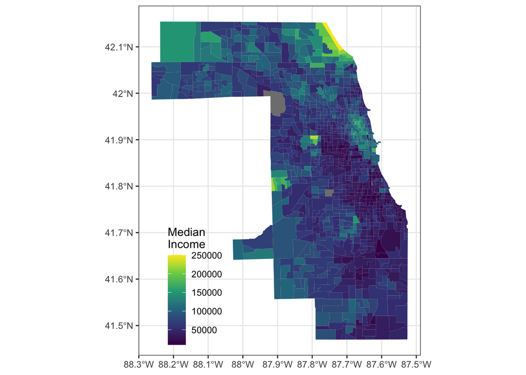

```r
invisible(lapply(packages, require, character.only=TRUE, quietly=TRUE,
                 warn.conflicts = FALSE))
options(tigris_use_cache = TRUE)

# Median Income
chicago <- get_acs(geography = "tract",
                   variables = "B19013_001",
                   state = "IL",
                   county = c("Cook"),
                   geometry = T)
chicago %>%
  ggplot(aes(fill = estimate)) +
  geom_sf(color = NA) +
  scale_fill_viridis_c()+
  theme_bw() + labs(fill = "Median\nIncome") +
  theme(legend.position = c(0.2, 0.2),
        legend.background = element_rect(fill = NA))
```

## Spatial Density of Pick ups and Drop offs in Nov 2019

From data, we observe 1005 tracts had pick ups and 1018 tracts had drop offs. We also observe that the density of pick ups and drop offs are significantly higher in the O’Hare airport (ORD), Chicago Midway Airport (MDW) and downtown area (Loop)

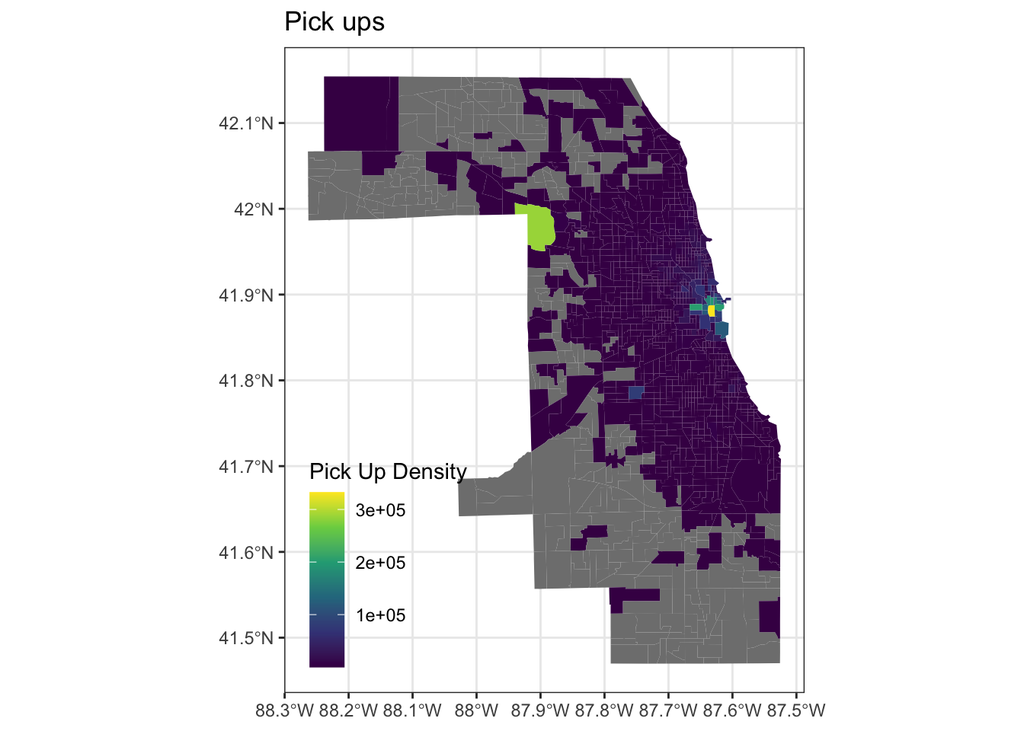

```r
### Visualize density of all Pick ups
pickups <- data %>%
  group_by(GEOID = data$Pickup.Census.Tract) %>%
  summarise("All_Pickups" = n()) %>%
  mutate(GEOID = as.character(GEOID))

chicago_pickups <- left_join(chicago, pickups, by = "GEOID")
chicago_pickups %>%
  ggplot(aes(fill = All_Pickups)) +
  geom_sf(color = NA) +
  scale_fill_viridis_c() +
  theme_bw() + labs(fill = "Pick Up Density") +
  theme(legend.position = c(0.2, 0.2),
        legend.background = element_rect(fill = NA))+
  labs(title = "Pick ups")
```

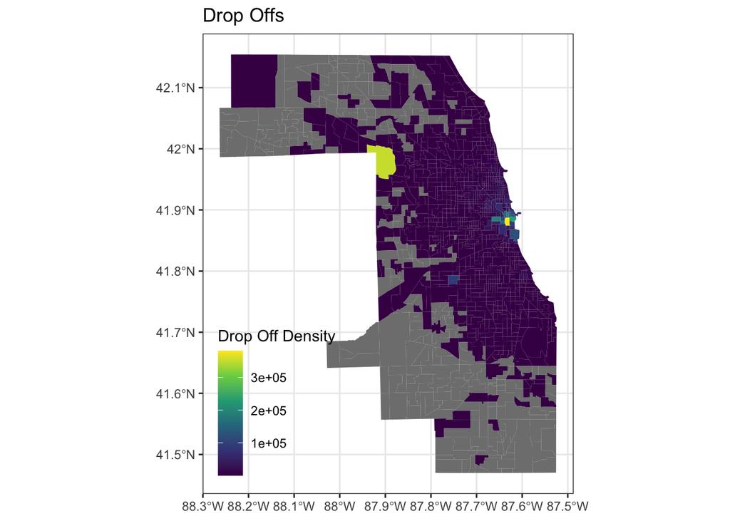

```r
### Visualize density of all drop offs
drops <- data %>%
  group_by(GEOID = data$Dropoff.Census.Tract) %>%
  summarise("All_Dropoffs" = n()) %>%
  mutate(GEOID = as.character(GEOID))

chicago_drops <- left_join(chicago, drops, by = "GEOID")
chicago_drops %>%
  ggplot(aes(fill = All_Dropoffs)) +
  geom_sf(color = NA) +
  scale_fill_viridis_c() +
  theme_bw() + labs(fill = "Drop Off Density") +
  theme(legend.position = c(0.2, 0.2),
        legend.background = element_rect(fill = NA)) +
  labs(title = "Drop Offs")
```

### Reduced Tracts

The Cook county has 518 census tracts more than the city of Chicago, so using the Cook country maps would result in unnecessarily large maps. Using the info from City of Chicago Data Portal, I filter only census tracts inside the boundary of city.

```r
chicago_tracts <- read.csv("CensusTractsTIGER2010.csv")
needed<-which(chicago$GEOID %in% chicago_tracts$GEOID10)
chicago <- chicago[needed,]
```

With this reduced map, I will lose nearly 200 tracts with pick ups and drop offs. However, upon a closer look, these tracts have very low density of pick up and drop offs. Note that I keep all tracts in the analysis but to make the maps clearer, I remove them from mapping.

## Origin-Destination Analysis

Since all trips are recorded as trip OD in census tracts, I can extract all OD pairs. I calculate the total number of trip between OD pairs and then find longitude and latitude for visualization. after extraction, I find 223,424 OD pairs. However, many of these OD pairs had only a few trips during Nov 2019. So I choose to remove OD pairs with less than 5 trips for visualization:

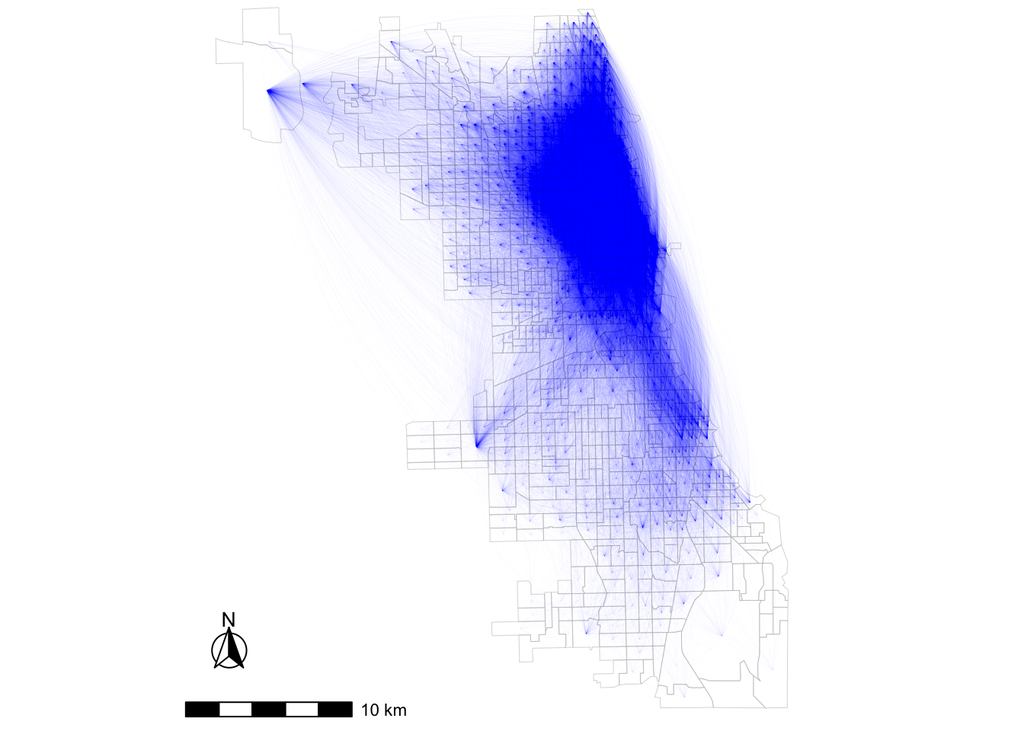

```r
require(ggspatial)

ODPAIRS <- data %>%
  group_by(Pickup.Census.Tract, Dropoff.Census.Tract) %>%
  summarise("pick.long" = median(Pickup.Centroid.Longitude, na.rm = T),
            "pick.lat" = median(Pickup.Centroid.Latitude, na.rm = T),
            "drop.long" = median(Dropoff.Centroid.Longitude, na.rm = T),
            "drop.lat" = median(Dropoff.Centroid.Latitude, na.rm = T),
            "sum.trip" = n())%>%
  filter(sum.trip > 5) %>% # exclude ODs with less than 5 trip in Nov 2019
  ungroup() %>%
  filter(!(Pickup.Census.Tract ==  Dropoff.Census.Tract)) %>% # remove OD in the same tract
  drop_na()



chicago %>%   ggplot() + geom_sf(color = "grey", fill = NA,  size = 0.1) +
  geom_curve(data = ODPAIRS, aes(x = pick.long, y = pick.lat,
                                   xend = drop.long, yend = drop.lat), size = 0.05, alpha = 0.05, color = "blue",  curvature = -0.2) +
  annotation_north_arrow(location = "bl", which_north = "true",
                         height = unit(1, "cm"), width = unit(1, "cm"),
                         pad_x = unit(0.5, "cm"), pad_y = unit(1, "cm"),
                         style = north_arrow_fancy_orienteering) +
  annotation_scale(location = "bl", width_hint = 0.25) + theme_void() +
  coord_sf(xlim = c(-87.95, -87.5), ylim = c(41.65, 42.01), expand = T)
```

The above figure shows the network of trips among 83,938 OD pairs in Nov 2019.

## Travel Impedance

Travel impedance measures are the variables that are resisting the travel ability. In general, trip fare, trip distance and trip duration are considered as main travel impedances. I consider the median and standard deviation of these variables to capture the variations in rider characteristics (riders who select different types of ridesourcing service, i.e., UberPool versus UberX), price fluctuations (e.g., surge pricing), traffic condition, route choice, etc. The median is chosen instead of mean to be robust to outlier while also measure the characteristics of a regular trip. Let’s take a look at the travel impedance:

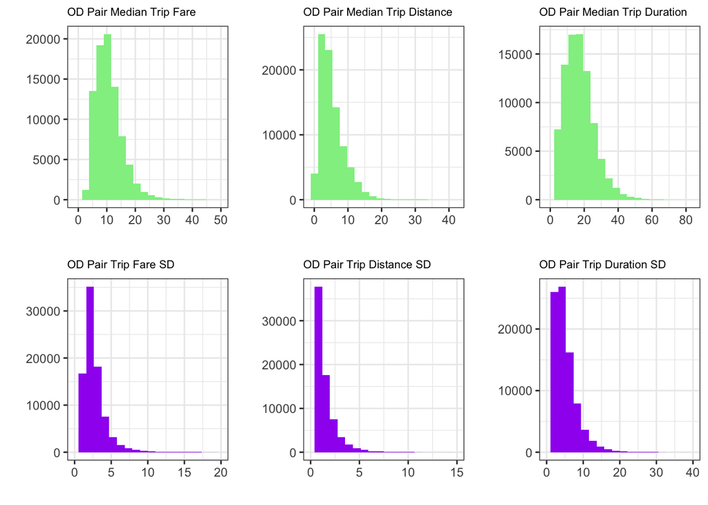

```r
impedance <- data %>%
  group_by(Pickup.Census.Tract, Dropoff.Census.Tract) %>%
  summarise("sum.trip" = n(),
            "trip.fare.median" = median(Fare, na.rm = T),
            "trip.distance.median" = median(Trip.Miles, na.rm = T),
            "trip.time.median" = median(Trip.Seconds/60, na.rm = T),
            "trip.fare.sd" = sd(Fare, na.rm = T),
            "trip.distance.sd" = sd(Trip.Miles, na.rm = T),
            "trip.time.sd" = sd(Trip.Seconds/60, na.rm = T))%>%
  filter(sum.trip > 5) %>% # exclude ODs with less than 5 trip in Nov 2019
  ungroup() %>%
  drop_na()

a1<- impedance %>%
  ggplot() +
  geom_histogram(aes(x = trip.fare.median), bins = 20, color = NA, fill = "lightgreen" )+
  theme_bw()+
  labs(title =  "OD Pair Median Trip Fare", y = "", x = "")+
  theme(plot.title = element_text(size = 8))

a2 <- impedance %>%
  ggplot() +
  geom_histogram(aes(x = trip.distance.median), bins = 20, color = NA, fill = "lightgreen")+
  theme_bw()+
  labs(title =  "OD Pair Median Trip Distance", y = "", x = "")+
  theme(plot.title = element_text(size = 8))

a3 <- impedance %>%
  ggplot() +
  geom_histogram(aes(x = trip.time.median), bins = 20, color = NA, fill = "lightgreen")+
  theme_bw()+
  labs(title =  "OD Pair Median Trip Duration", y = "", x = "")+
  theme(plot.title = element_text(size = 8))


a4 <- impedance %>%
  ggplot() +
  geom_histogram(aes(x = trip.fare.sd), bins = 20, color = NA, fill = "purple")+
  theme_bw()+
  labs(title =  "OD Pair Trip Fare SD", y = "", x = "") + xlim(0,20)+
  theme(plot.title = element_text(size = 8))

a5 <- impedance %>%
  ggplot() +
  geom_histogram(aes(x = trip.distance.sd), bins = 20, color = NA, fill = "purple")+
  theme_bw()+
  labs(title =  "OD Pair Trip Distance SD", y = "", x = "") + xlim(0,15)+
  theme(plot.title = element_text(size = 8))

a6 <- impedance %>%
  ggplot() +
  geom_histogram(aes(x = trip.time.sd),  bins = 20, color = NA, fill = "purple")+
  theme_bw()+
  labs(title =  "OD Pair Trip Duration SD", y = "", x = "") + xlim(0,40) +
  theme(plot.title = element_text(size = 8))

plot_grid(a1,a2,a3,a4,a5,a6, nrow = 2, align="v")
```

## Equity In Chicago

Using the definition of **Dissimilarity** and **Isolation** by Culter et al. (1999) we look at the spatial equity in Chicago:

*Cutler, David M., Edward L. Glaeser, and Jacob L. Vigdor. “The rise and decline of the American ghetto.” Journal of political economy 107.3 (1999): 455-506.*

Focusing on the African Americans, the plot here shows the dissimilarity index in each tract. The next plot shows the population of African Americans to the total population of the tract. Unsurprisingly, the correlation of dissimilarity and the population of African Americans is around 89%

```r
# Total population by tract
chicago <- get_acs(geography = "tract",
                   variables = c("B01001_001") ,
                   state = "IL",
                   county = c("Cook"),
                   geometry = TRUE)
#AA population by tract
chicago1 <- get_acs(geography = "tract",
                   variables = c("B02009_001") ,
                   state = "IL",
                   county = c("Cook"),
                   geometry = TRUE)
chicago$AA <- chicago1$estimate
remove(chicago1)

#Proportion of AA
chicago$prop_AA<- chicago$AA/sum(chicago$AA)

#Proportion of non AA
chicago$prop_AAc <- chicago$estimate - chicago$AA
chicago$prop_AAc <- chicago$prop_AAc/sum(chicago$prop_AAc)

#Proportion of AA to popultion of tract
chicago$prop_AA_all <- chicago$AA/chicago$estimate


#Dissimilarity
chicago$dissimilarity <- chicago$prop_AA - chicago$prop_AAc


#Isolation Index
chicago$prop_AA_t <- chicago$AA / chicago$estimate

prop_AA_city <- sum(chicago$AA)/sum(chicago$estimate)
prop_AA_city
```

```
## [1] 0.2452404
```

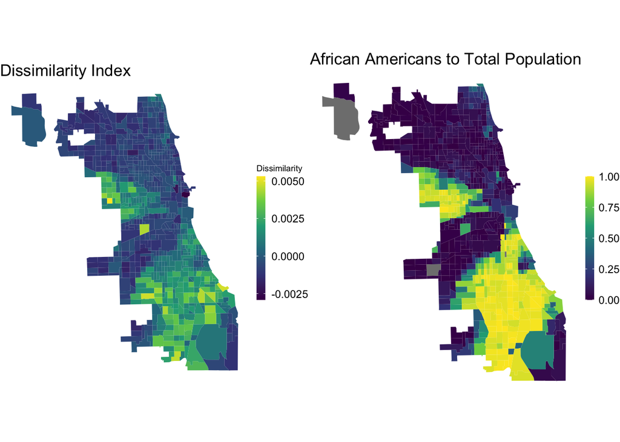

```r
indices<-data.frame(index=factor(c("Dissimilarity", "Isolation")), value=rep(NA,2))

indices$value[indices$index=="Dissimilarity"]<-0.5*sum(abs(chicago$dissimilarity))
indices$value[indices$index=="Isolation"]<-(sum(chicago$prop_AA * chicago$prop_AA_t, na.rm = T) - prop_AA_city)/(1-prop_AA_city)


chicago_tracts <- read.csv("/Users/taiebat/Desktop/CensusTractsTIGER2010.csv")
needed<-which(chicago$GEOID %in% chicago_tracts$GEOID10)
chicago <- chicago[needed,]


p1 <- chicago %>%
  ggplot(aes(fill = dissimilarity)) +
  geom_sf(color = NA) +
  scale_fill_viridis_c()+ theme_void() +
  labs(title = "Dissimilarity Index",
       fill = "Dissimilarity") +
  theme(legend.title = element_text(size = 7)) +
  guides(fill = guide_colourbar(barwidth = 0.5, barheight = 7))



p2<- chicago %>%
  ggplot(aes(fill = prop_AA_all)) +
  geom_sf(color = NA) +
  scale_fill_viridis_c() + theme_void() +
  labs(title = "African Americans to Total Population",
       fill = "") +
  theme(legend.title = element_text(size = 7))+
  guides(fill = guide_colourbar(barwidth = 0.5, barheight = 7))


plot_grid(p1, p2)
```

```r
cor(chicago$dissimilarity, chicago$prop_AA_all, use = "pairwise.complete.obs" )
```

```
## [1] 0.8840024
```

```r
# Show Indices
indices
```

```
##           index     value
## 1 Dissimilarity 0.7420806
## 2     Isolation 0.6061238
```

We can also see that the Dissimilarity index is 0.74, and the Isolation index is 0.61 based on 2018 data, both of which above the 0.6 threshold stated in Culter et al (1999), showing high level of neighborhood segregation in the city of Chicago.